# 4.9 Task Part 2

## Importing Libraries

```python
import pandas as pd
import numpy as np
import os
import matplotlib.pyplot as plt
import seaborn as sns
import scipy
```

## Importing Data

```python
# Establishing path

path = r'/Users/Kate/Documents/Instacart Basket Analysis'
```

```python
# Importing data

df_opc = pd.read_pickle(os.path.join(path, '02 Data', 'Prepared Data', 'orders_products_customers_final.pkl'))
```

```python
df_opc.shape
```

```
(32404859, 26)
```

```python
df_opc.head()
```

|  | order_id | user_id | order_number | orders_day_of_week | order_hour_of_day | days_since_prior_order | product_id | add_to_cart_order | reordered | product_name | ... | busiest_period_of_day | max_order | loyalty_flag | gender | state | age | date_joined | dependants | family_status | income |
| --- | --- | --- | --- | --- | --- | --- | --- | --- | --- | --- | --- | --- | --- | --- | --- | --- | --- | --- | --- | --- | --- |
| 0 | 2539329 | 1 | 1 | 2 | 8 | NaN | 196 | 1 | 0 | Soda | ... | Average orders | 10 | New customer | Female | Alabama | 31 | 2/17/2019 | 3 | married | 40423 |
| 1 | 2398795 | 1 | 2 | 3 | 7 | 15.0 | 196 | 1 | 1 | Soda | ... | Average orders | 10 | New customer | Female | Alabama | 31 | 2/17/2019 | 3 | married | 40423 |
| 2 | 473747 | 1 | 3 | 3 | 12 | 21.0 | 196 | 1 | 1 | Soda | ... | Most orders | 10 | New customer | Female | Alabama | 31 | 2/17/2019 | 3 | married | 40423 |
| 3 | 2254736 | 1 | 4 | 4 | 7 | 29.0 | 196 | 1 | 1 | Soda | ... | Average orders | 10 | New customer | Female | Alabama | 31 | 2/17/2019 | 3 | married | 40423 |
| 4 | 431534 | 1 | 5 | 4 | 15 | 28.0 | 196 | 1 | 1 | Soda | ... | Most orders | 10 | New customer | Female | Alabama | 31 | 2/17/2019 | 3 | married | 40423 |

5 rows × 26 columns

### 2. If you haven’t done so already, follow the instructions in the Exercise to create a bar chart, a histogram, a scatterplot, and a line chart, using a sample subset for the line chart.

### Bar Charts

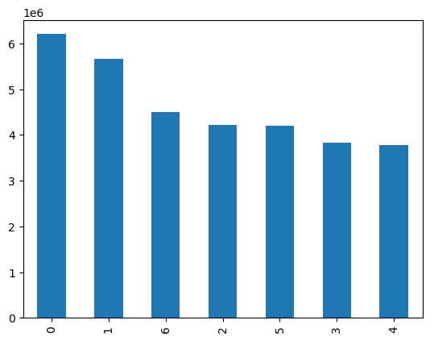

```python
# Creating 'orders_day_of_week' bar chart

df_opc['orders_day_of_week'].value_counts().plot.bar()
```

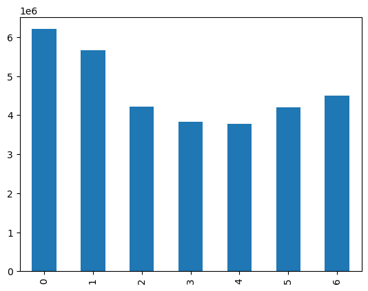

```python
# Bar chart in chronological order

bar = df_opc['orders_day_of_week'].value_counts().sort_index().plot.bar()
```

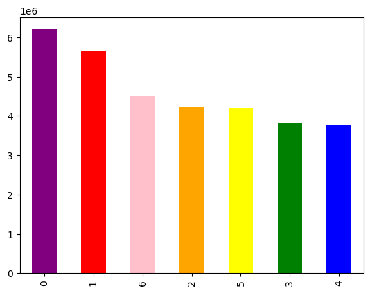

```python
# Adding color to bar chart

df_opc['orders_day_of_week'].value_counts().plot.bar(color = ['purple', 'red', 'pink', 'orange', 'yellow', 'green', 'blue'])
```

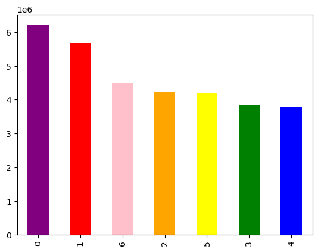

```python
# Saving bar chart

bar = df_opc['orders_day_of_week'].value_counts().plot.bar(color = ['purple', 'red', 'pink', 'orange', 'yellow', 'green', 'blue'])
```

```python
# Exporting saved bar chart to img file

bar.figure.savefig(os.path.join(path, '04 Analysis','Visualizations', 'bar_orders_dow_2.png'))
```

### Histograms

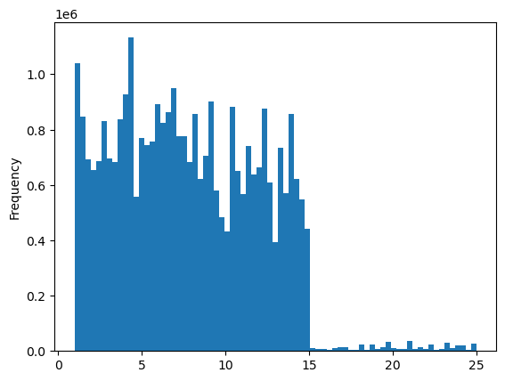

```python
# Creating a histogram for 'prices'

hist_prices = df_opc['prices'].plot.hist(bins = 75)
```

### Scatterplot

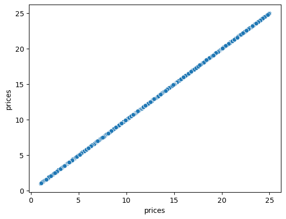

```python
# Making a scatterplot

scatterplot_prices = sns.scatterplot(x = 'prices', y = 'prices',data = df_opc)
```

### Sampling Data

```python
# Creating a sample

np.random.seed(4)
dev = np.random.rand(len(df_opc)) <= 0.7
```

```python
dev
```

```
array([False,  True, False, ...,  True,  True,  True])
```

```python
# Splitting the df into 2 samples

big = df_opc[dev]
small = df_opc[~dev]
```

```python
# Checking the size of big and small

len(df_opc)
```

```
32404859
```

```python
len(big) + len(small)
```

```
32404859
```

```python
# Creating a new df that only contains 'prices' and 'orders_day_of_week'

df_2 = small[['orders_day_of_week', 'prices']]
```

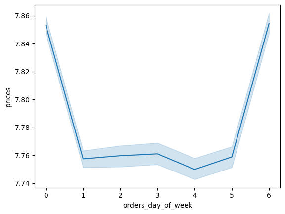

```python
# Creating a line chart

linechart_prices = sns.lineplot(data = df_2, x = 'orders_day_of_week', y = 'prices')
```

### 3. You need to provide the Instacart senior stakeholders with descriptive findings about sales. Create a histogram of the “order_hour_of_day” column.

In a markdown cell beneath your histogram, describe what the histogram demonstrates.

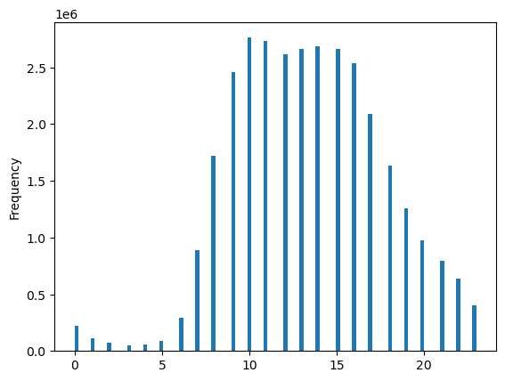

```python
# Creating a histogram for 'order_hour_of_day'

hist_order_hour = df_opc['order_hour_of_day'].plot.hist(bins = 100)
```

This histogram shows the frequency of orders during each hour of the day.

### 4. The marketing team is curious about the distribution of orders among customers in terms of loyalty. Create a bar chart from the “loyalty_flag” column.

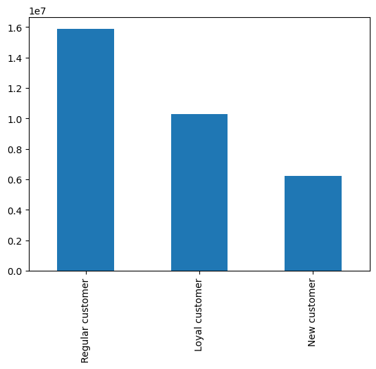

```python
# Creating 'loyalty_flag' bar chart

barchart_loyalty = df_opc['loyalty_flag'].value_counts().plot.bar()
```

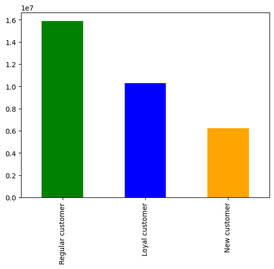

```python
# adding color to the bar chart

barchart_loyalty_color = df_opc['loyalty_flag'].value_counts().plot.bar(color = ['green', 'blue', 'orange'])
```

### 5. Check whether there’s a difference in expenditure (the “prices” column) depending on the hour of the day. (Hint: To check this, you need to use an accurate sample for your line chart!)

```python
# Creating a sample df that only contains 'prices' and 'orders_day_of_week'

df_orders_prices = small[['order_hour_of_day', 'prices']]
```

```python
df_orders_prices.head()
```

|  | order_hour_of_day | prices |
| --- | --- | --- |
| 0 | 8 | 9.0 |
| 2 | 12 | 9.0 |
| 3 | 7 | 9.0 |
| 6 | 9 | 9.0 |
| 10 | 8 | 12.5 |

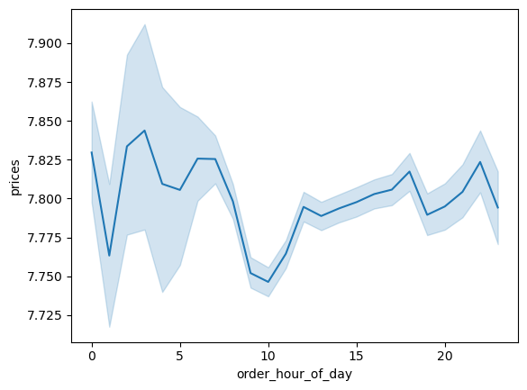

```python
# Creating a line chart for df_orders_prices

linechart_orders_prices = sns.lineplot(data = df_orders_prices, x = 'order_hour_of_day', y = 'prices')
```

### 6. Now that you have information about customers, you need to conduct some exploratory analysis of customer demographics to inform the targeted marketing campaigns. First, determine whether there’s a connection between age and family situation by creating a line chart exploring the connections between age and number of dependents:

In a markdown cell beneath your line chart, describe what the line chart shows.

```python
# Creating a sample df that only contains 'age' and 'dependants'

df_age_dependants = small[['age', 'dependants']]
```

```python
df_age_dependants.head()
```

|  | age | dependants |
| --- | --- | --- |
| 0 | 31 | 3 |
| 2 | 31 | 3 |
| 3 | 31 | 3 |
| 6 | 31 | 3 |
| 10 | 31 | 3 |

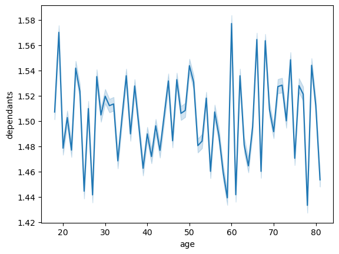

```python
# Creating a line chart for df_age_dependants

linechart_age_dependants = sns.lineplot(data = df_age_dependants, x = 'age', y = 'dependants')
```

This line chart shows the connection between 'age' and 'dependants'. It seems like there isn't a clear connection between the two.

### 7. You’ll also need to explore whether there’s a connection between age and spending power (income). To visualize this relationship, create a scatterplot using the sns.scatterplot() function.

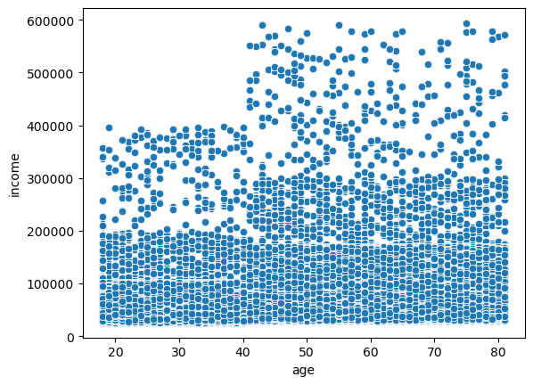

```python
# Making a scatterplot

scatterplot_age_income = sns.scatterplot(x = 'age', y = 'income',data = df_opc)
```

### 8. Export your visualizations as “.png” files in your relevant project folder.

```python
# Exporting charts to img files

bar.figure.savefig(os.path.join(path, '04 Analysis','Visualizations', 'bar_orders_dow_2.png'))
```

```python
hist_prices.figure.savefig(os.path.join(path, '04 Analysis','Visualizations', 'hist_prices.png'))
```

```python
scatterplot_prices.figure.savefig(os.path.join(path, '04 Analysis','Visualizations', 'scatterplot_prices.png'))
```

```python
linechart_prices.figure.savefig(os.path.join(path, '04 Analysis','Visualizations', 'linechart_prices.png'))
```

```python
hist_order_hour.figure.savefig(os.path.join(path, '04 Analysis','Visualizations', 'hist_order_hour.png'))
```

```python
barchart_loyalty_color.figure.savefig(os.path.join(path, '04 Analysis','Visualizations', 'barchart_loyalty_color.png'))
```

```python
linechart_orders_prices.figure.savefig(os.path.join(path, '04 Analysis','Visualizations', 'linechart_orders_prices.png'))
```

```python
linechart_age_dependants.figure.savefig(os.path.join(path, '04 Analysis','Visualizations', 'linechart_age_dependants.png'))
```

```python
scatterplot_age_income.figure.savefig(os.path.join(path, '04 Analysis','Visualizations', 'scatterplot_age_income.png'))
```